# Feature Selection: Practical 2

Comparing Feature Selection Methods

Solon Karapanagiotis

21-04-2026

© 2026 Solon Karapanagiotis. All rights reserved.

High-dimensional binary classification problem designed to test different feature selection methods.

# 1 Setup

```r
library(caret)
library(pROC)
library(dplyr)
```

# 2 Dataset

The dataset contains:

- 500 observations,
- 100 features (X1–X100),
- a binary outcome $y \in \{0,1\}$.

```r
load(here::here("data", "data_practical2.Rdata"))
```

```r
str(data)
```

```
## 'data.frame':    500 obs. of  101 variables:
##  $ y   : int  1 1 1 1 1 0 1 1 0 0 ...
##  $ X1  : num  0.175 -1.102 0.969 0.34 0.475 ...
##  $ X2  : num  -0.256 -0.416 1.589 -0.035 0.171 ...
##  $ X3  : num  -0.061 -1.614 -0.339 1.306 0.153 ...
##  $ X4  : num  -0.83 -1.31 0.357 0.457 0.376 ...
##  $ X5  : num  -0.218 0.238 0.735 1.636 -0.527 ...
##  $ X6  : num  -0.679 0.574 -0.705 -0.534 0.774 ...
##  $ X7  : num  -0.15 -0.328 -1.448 -0.697 2.598 ...
##  $ X8  : num  1.478 -1.407 -1.884 -0.277 0.43 ...
##  $ X9  : num  0.197 0.65 0.671 -1.284 -2.026 ...
##  $ X10 : num  0.834 -0.698 1.309 -0.98 0.748 ...
##  $ X11 : num  -0.494 1.128 -1.147 1.481 0.916 ...
##  $ X12 : num  -1.357 -1.293 -1.517 0.859 -1.215 ...
##  $ X13 : num  -0.699 0.996 -0.693 -0.103 0.604 ...
```

[output cut: 86 more lines]

This code splits the dataset into training and test sets using a stratified sampling approach.

First, `set.seed(1)` ensures the split is reproducible. The function `createDataPartition()` from the caret package creates a partition of the outcome variable y, selecting 70% of the observations for training while preserving the original class distribution. This is important in binary classification to avoid imbalance between classes in the split.

```r
set.seed(1)
trainIndex <- caret::createDataPartition(data$y, p = .7, list = FALSE)
train <- data[trainIndex, ]
test  <- data[-trainIndex, ]
```

# 3 Feature Selection

The `glm()` fits a logistic regression using all predictors in the training set to predict $y$. This serves as a simple benchmark model with no feature selection.

```r
baseline_model <- glm(y ~ ., data = train, family = "binomial")

# generate predicted probabilities for the test set
pred <- predict(baseline_model, test, type = "response")

# model performance is evaluated using the Area Under the ROC Curve (AUC)
baseline_auc <- pROC::roc(test$y, pred, direction = "<")$auc
baseline_auc
```

```
## Area under the curve: 0.7078
```

## 3.1 Filter Methods

### 3.1.1 Univariate tests based on p-value

```r
# Univariate tests based on p-value
pvals <- sapply(train[,-1], function(x){
  summary(glm(train$y ~ x, family = "binomial"))$coeff[2,4]
})

filter_features <- names(sort(pvals))[1:10]
filter_features
```

```
##  [1] "X1"  "X2"  "X4"  "X3"  "X5"  "X11" "X17" "X56" "X73" "X25"
```

```r
formula_filter <- as.formula(
    paste("y ~", paste(filter_features, collapse = "+"))
)

filter_model <- glm(formula_filter, data = train, family = "binomial")

pred <- predict(filter_model, test, type = "response")
filter_auc <- pROC::roc(test$y, pred)$auc
filter_auc
```

```
## Area under the curve: 0.813
```

> Note: For our purposes, the p-values are being used algorithmically to search for appropriate subsets, especially since it is a convenient quantity to use when dealing with different feature types. It is very important to not take p-values generated in such processes as meaningful or formal indicators of statistical significance.

### 3.1.2 Mutual Information

Mutual information (MI) is a concept from information theory that measures the dependence between two variables. It quantifies how much knowing one variable reduces uncertainty about another.

#### 3.1.2.1 Intuition

Mutual information answers the question:

> How much information about Y do we gain by observing X?
- If X and Y are independent MI = 0
- If X strongly predicts Y MI is high
- If X partially relates to Y MI is between 0 and high

#### 3.1.2.2 Mathematical definition

MI between X and Y is defined as:

$$I(X;Y) = \sum_{x \in X} \sum_{y \in Y}
p(x,y)\log\left(\frac{p(x,y)}{p(x)p(y)}\right)$$

This compares:

- the joint distribution $p(x,y)$
- with the distribution under independence $p(x)p(y)$

An equivalent form is

$$I(X;Y) = H(Y) - H(Y|X)$$

where:

- $H(Y)$ is the entropy (uncertainty) of Y
- $H(Y|X)$ is the remaining uncertainty in Y after observing X

MI measures the reduction in uncertainty about the outcome after observing a feature.

- Higher MI → more informative feature
- Lower MI → less informative feature

```r
# Mutual Information
library(FSelectorRcpp)

info_gain <- information_gain(y ~ ., data = train)

head(info_gain)
```

|  | attributes | importance |
| --- | --- | --- |
| 1 | X1 | 0.12403500 |
| 2 | X2 | 0.11153409 |
| 3 | X3 | 0.09838807 |
| 4 | X4 | 0.07826217 |
| 5 | X5 | 0.08618419 |
| 6 | X6 | 0.00000000 |

```r
# Sort variables by importance:
mi_features <- info_gain %>%
  arrange(desc(importance)) %>%
  slice(1:10) %>%
  pull(attributes)

mi_features
```

```
##  [1] "X1"  "X2"  "X3"  "X5"  "X4"  "X8"  "X11" "X6"  "X7"  "X9"
```

```r
# Train model using MI-selected features
formula_mi <- as.formula(
  paste("y ~", paste(mi_features, collapse = "+"))
)

mi_model <- glm(formula_mi, data = train, family = "binomial")

pred <- predict(mi_model, test, type = "response")
mi_auc <- pROC::roc(test$y, pred)$auc
mi_auc
```

```
## Area under the curve: 0.8363
```

## 3.2 Wrapper methods

### 3.2.1 Stepwise regression

```r
# Stepwise regression
step_model <- step(glm(y ~ ., data = train, family = "binomial"),
                   direction = "both", trace = 0)

summary(step_model)$coefficients
```

```
##               Estimate Std. Error   z value     Pr(>|z|)
## (Intercept)  1.6603859  0.2746134  6.046267 1.482405e-09
## X1           2.0105631  0.4415946  4.552961 5.289602e-06
## X2           1.5481001  0.4225651  3.663578 2.487168e-04
## X5          -0.7316268  0.3723825 -1.964718 4.944684e-02
## X11          2.6305050  0.3863254  6.809039 9.825251e-12
## X17         -0.6721931  0.1876370 -3.582412 3.404364e-04
## X21         -0.5331233  0.2234158 -2.386238 1.702171e-02
## X22          0.7394901  0.2108249  3.507604 4.521617e-04
## X24          0.5407631  0.2026331  2.668681 7.614974e-03
## X25          0.7430724  0.2030881  3.658868 2.533319e-04
## X27         -0.3180044  0.2105548 -1.510317 1.309626e-01
## X28          0.5133329  0.2184896  2.349462 1.880058e-02
## X29         -0.4559648  0.2103365 -2.167787 3.017491e-02
## X30          0.3862560  0.2022449  1.909842 5.615351e-02
## X38         -0.4762863  0.2222350 -2.143165 3.209984e-02
## X39          0.3310146  0.2118277  1.562660 1.181326e-01
## X40          0.2944005  0.2056403  1.431628 1.522503e-01
## X42         -0.4063289  0.2174090 -1.868961 6.162824e-02
## X43          0.6045384  0.2044326  2.957153 3.104937e-03
## X47          0.5676801  0.2015105  2.817124 4.845581e-03
## X51         -0.3299311  0.2118864 -1.557113 1.194437e-01
## X52          0.4408716  0.2031533  2.170142 2.999605e-02
## X54         -0.4666555  0.2180844 -2.139793 3.237148e-02
## X61         -0.5758912  0.2005937 -2.870934 4.092611e-03
## X62          0.3741366  0.2496224  1.498810 1.339229e-01
## X64         -0.6587963  0.2027117 -3.249917 1.154385e-03
## X66          0.6364324  0.2173752  2.927806 3.413626e-03
## X68         -0.6273787  0.2039766 -3.075738 2.099820e-03
## X70          0.2787847  0.1872390  1.488924 1.365073e-01
## X72         -0.6062868  0.2152762 -2.816320 4.857723e-03
## X74          0.3201293  0.1989741  1.608899 1.076384e-01
## X78         -0.4798761  0.2101866 -2.283096 2.242473e-02
## X80         -0.3513132  0.1992877 -1.762845 7.792669e-02
## X82          0.4124697  0.1810528  2.278173 2.271626e-02
## X87         -0.3324481  0.2040607 -1.629163 1.032785e-01
## X88         -0.3017567  0.1944212 -1.552077 1.206437e-01
## X89         -0.3319417  0.1985953 -1.671448 9.463330e-02
## X90          0.3221719  0.1821962  1.768269 7.701600e-02
## X91          0.5820303  0.2082294  2.795140 5.187728e-03
## X92         -0.7950135  0.2173109 -3.658415 2.537801e-04
## X93          0.4682050  0.2024645  2.312528 2.074859e-02
## X95          0.6015856  0.2166031  2.777364 5.480172e-03
## X98         -0.4351488  0.2115686 -2.056775 3.970792e-02
```

```r
pred <- predict(step_model, test, type = "response")
step_auc <- pROC::roc(test$y, pred)$auc
step_auc
```

```
## Area under the curve: 0.7201
```

### 3.2.2 Recursive Feature Elimination (RFE)

First, we define the RFE control setting using `rfeControl()`: RFE will repeatedly train logistic regression models and evaluate them using 5-fold CV. We also need to specify how many features RFE should try: models with 5, 10, 15, 20, and 30 features. The algorithm will determine which size gives the best performance. We then run the RFE (`rfe()`).

Algorithm: For each subset size (e.g., 5, 10, …):

1. Fit a logistic regression model
2. Rank variables by importance
3. Remove the least important features
4. Evaluate performance using cross-validation
5. Store the best-performing subset

```r
# RFE

# Define the RFE control settings
ctrl <- caret::rfeControl(functions = lrFuncs, # uses logistic regression as the underlying model
                   method = "cv",
                   number = 5)

# specify how many features RFE should try
sizes <- c(5, 10, 15, 20, 30)

set.seed(123)

# y needs to be a factor in `rfe()`
train$y <- as.factor(train$y)

rfe_model <- rfe(
    x = train[, -1],
    y = train$y,
    sizes = sizes,
    rfeControl = ctrl
)

rfe_model
```

```
##
## Recursive feature selection
##
## Outer resampling method: Cross-Validated (5 fold)
##
## Resampling performance over subset size:
##
##  Variables Accuracy  Kappa AccuracySD KappaSD Selected
##          5   0.7574 0.4521    0.05859 0.13489        *
##         10   0.7517 0.4457    0.04090 0.08702
##         15   0.7343 0.4029    0.03939 0.08073
##         20   0.7143 0.3532    0.04694 0.10469
##         30   0.7084 0.3493    0.01909 0.06820
##        100   0.6969 0.3550    0.03948 0.07877
##
## The top 5 variables (out of 5):
##    X11, X64, X80, X95, X4
```

```r
rfe_features <- predictors(rfe_model)
rfe_features
```

```
## [1] "X11" "X64" "X80" "X95" "X4"
```

```r
formula_rfe <- as.formula(
    paste("y ~", paste(rfe_features, collapse = "+"))
)

rfe_glm <- glm(formula_rfe, data = train, family = "binomial")

pred <- predict(rfe_glm, test, type = "response")
rfe_auc <- pROC::roc(test$y, pred)$auc
rfe_auc
```

```
## Area under the curve: 0.802
```

## 3.3 Embedded methods

### 3.3.1 Lasso

```r
# Lasso
library(glmnet)
```

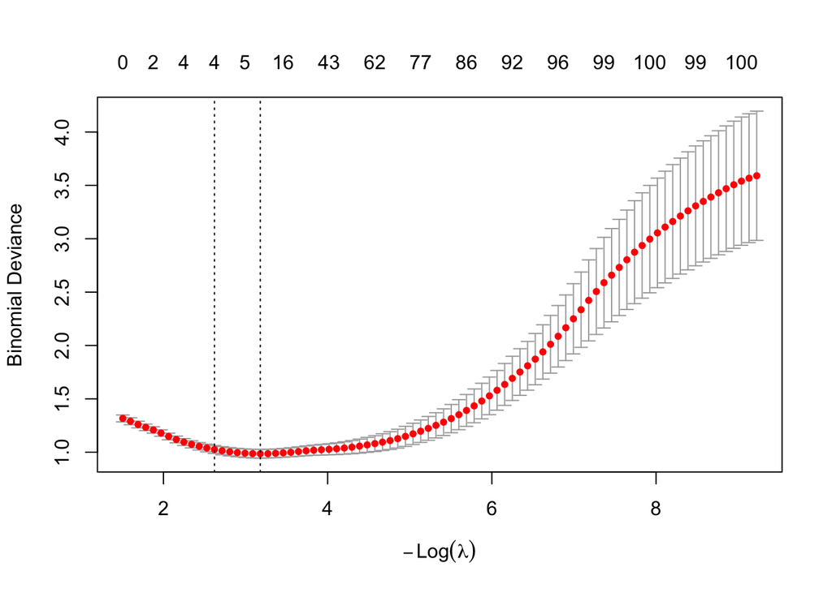

```r
x_train <- model.matrix(y ~ ., train)[,-1]
y_train <- train$y

cv_lasso <- cv.glmnet(x_train, y_train, family = "binomial", alpha = 1)

plot(cv_lasso)
```

```r
lasso_coef <- coef(cv_lasso, s = "lambda.min")
lasso_features <- rownames(lasso_coef)[lasso_coef[,1] != 0]
lasso_features
```

```
## [1] "(Intercept)" "X1"          "X2"          "X4"          "X11"
## [6] "X17"         "X56"         "X73"         "X90"
```

```r
x_test <- model.matrix(y ~ ., test)[,-1]
pred <- predict(cv_lasso, s = "lambda.1se", newx = x_test, type = "response")

lasso_auc <- pROC::roc(test$y, pred)$auc
lasso_auc
```

```
## Area under the curve: 0.8437
```

### 3.3.2 Gradient Boosting Trees

Gradient Boosting Trees is an ensemble learning method that builds a model by combining many small decision trees in a sequential way.

Instead of fitting a single large tree, the model builds trees one at a time, where each new tree focuses on correcting the mistakes made by the previous model.

#### 3.3.2.1 Core idea

The model is built in an additive form:

$$\hat{f}(x) = \sum_{m=1}^{M}
T_m(x)$$

where each $T_m(x)$ is a small decision tree. Each new tree is added to improve the overall prediction.

#### 3.3.2.2 How it works step-by-step

#### 3.3.2.3 1. Start with a simple prediction

The model begins with an initial guess:

- For regression: the mean of $y$
- For classification: the log-odds of the outcome

#### 3.3.2.4 2. Compute errors (residuals)

The model calculates the difference between observed and predicted values:

$$\text{error} = y - \hat{y}$$

These errors represent what the model has not yet learned.

#### 3.3.2.5 3. Fit a tree to the errors

A small decision tree (weak learner) is trained to predict these residuals.

Importantly:

- The tree does not predict $y$ directly
- It predicts the remaining error

#### 3.3.2.6 4. Update the model

The new tree is added to improve predictions:

$$\hat{y}_{new} = \hat{y}_{old} + \eta
\cdot T_m(x)$$

where:

- $\eta$ is the learning rate (controls step size)
- $T_m(x)$ is the new tree

#### 3.3.2.7 5. Repeat the process

Steps 2–4 are repeated many times:

- Each tree corrects previous mistakes
- The model gradually improves

The XGBoost package implements a fast gradient-boosted decision tree algorithm. The model builds 100 sequential decision trees.

Then we compute how important each feature is based on:

- how often it is used in splits
- how much it improves model performance.

```r
# Boosting
library(xgboost)

xgb_model <- xgboost(x = x_train,
                     y = y_train,
                     nrounds = 100, # number of boosting iterations (trees)
                     objective = "binary:logistic")

importance_matrix <- xgb.importance(model = xgb_model)

xgb_features <- importance_matrix$Feature[1:10]
xgb_features
```

```
##  [1] "X1"  "X11" "X8"  "X4"  "X2"  "X72" "X95" "X9"  "X17" "X25"
```

```r
pred <- predict(xgb_model, x_test)

xgb_auc <- pROC::roc(test$y, pred)$auc
xgb_auc
```

```
## Area under the curve: 0.8454
```

# 4 Summary

```r
# =========================
# SUMMARY OF RESULTS
# =========================

results <- data.frame(
  Method = c(
    "Baseline (all features)",
    "Filter (p-value)",
    "Filter (Mutual Information)",
    "Wrapper (Stepwise)",
    "Wrapper (RFE)",
    "Embedded (LASSO)",
    "Embedded (XGBoost)"
  ),

  AUC = c(
    baseline_auc,
    filter_auc,
    mi_auc,
    step_auc,
    rfe_auc,
    lasso_auc,
    xgb_auc
  ),

  Selected_Variables = c(
    "All features",
    paste(filter_features, collapse = ", "),
    paste(mi_features, collapse = ", "),
    paste(names(coef(step_model))[coef(step_model) != 0], collapse = ", "),
    paste(rfe_features, collapse = ", "),
    paste(lasso_features, collapse = ", "),
    paste0("Variable importance (no explicit subset) - top 10:", paste0(xgb_features, collapse = ", "))
  )
)
```

```r
results %>% arrange(desc(AUC))
```

| Method | AUC | Selected_Variables |
| --- | --- | --- |
| Embedded (XGBoost) | 0.8454088 | Variable importance (no explicit subset) - top 10:X1, X11, X8, X4, X2, X72, X95, X9, X17, X25 |
| Embedded (LASSO) | 0.8437325 | (Intercept), X1, X2, X4, X11, X17, X56, X73, X90 |
| Filter (Mutual Information) | 0.8362824 | X1, X2, X3, X5, X4, X8, X11, X6, X7, X9 |
| Filter (p-value) | 0.8130006 | X1, X2, X4, X3, X5, X11, X17, X56, X73, X25 |
| Wrapper (RFE) | 0.8020115 | X11, X64, X80, X95, X4 |
| Wrapper (Stepwise) | 0.7200596 | (Intercept), X1, X2, X5, X11, X17, X21, X22, X24, X25, X27, X28, X29, X30, X38, X39, X40, X42, X43, X47, X51, X52, X54, X61, X62, X64, X66, X68, X70, X72, X74, X78, X80, X82, X87, X88, X89, X90, X91, … |
| Baseline (all features) | 0.7077668 | All features |

# 5 Discussion

- Which method achieved best predictive performance?
- Which features appear in every method?